# MTH6139 Time Series

Coursework 1 Gold Prices

Shaivi Darsi

Spring term 2025

# 1. Introduction

This project analyses historical daily gold prices from 1970 to 2026 and applies the Prophet model to forecast future values. Gold is widely considered a safe-haven asset, which means its price increases during periods of economic uncertainty.

The aim of this project is to explore trends in gold prices, build a forecasting model, evaluate the importance of seasonality, and compare forecasts using recent data.

# 2. Data Preparation

## 2.1 Loading the data

```r
gold_data <- read.csv("data/gold_price_1970_2026_daily.csv", stringsAsFactors = FALSE)
str(gold_data)
```

```
## 'data.frame':    20819 obs. of  7 variables:
##  $ Date     : chr  "1/1/1970" "1/2/1970" "1/3/1970" "1/4/1970" ...
##  $ Open     : num  35.3 35.1 35.4 35.9 35.8 ...
##  $ High     : num  35.3 35.2 35.4 36.1 35.9 ...
##  $ Low      : num  35 35.1 35.3 35.8 35.7 ...
##  $ Close    : num  35.2 35.1 35.4 35.9 35.9 ...
##  $ Volume   : int  463815 118078 268897 441570 443895 369914 367899 339524 215043 332336 ...
##  $ USD_Index: num  101.7 99.6 99.4 99.7 99.9 ...
```

```r
head(gold_data)
```

```
##       Date     Open     High      Low    Close Volume USD_Index
## 1 1/1/1970 35.26648 35.34705 35.02873 35.18484 463815 101.65398
## 2 1/2/1970 35.11844 35.21060 35.11303 35.14676 118078  99.60224
## 3 1/3/1970 35.39048 35.40160 35.30880 35.38576 268897  99.37285
## 4 1/4/1970 35.87716 36.12963 35.81995 35.93960 441570  99.68926
## 5 1/5/1970 35.84976 35.91335 35.72434 35.86630 443895  99.94307
## 6 1/6/1970 35.79759 35.98335 35.69822 35.79316 369914 100.01784
```

The dataset contains daily gold prices recorded from 1970 to 2026. In this project, we focus on the closing price. For further analysis we can also look at the open, high and low prices in this datset.

## 2.2 Cleaning column names

```r
names(gold_data) <- trimws(names(gold_data))
names(gold_data) <- tolower(names(gold_data))
```

Column names are cleaned to remove spaces and capital letters to ensure consistency.

## 2.3 Converting dates

```r
library(lubridate)
gold_data$date <- mdy(gold_data$date)
gold_data <- gold_data[!is.na(gold_data$date), ]
```

The date column is converted into a proper date format that prophet can understand as this datset’s date format is slightly different. The missing values are removed as well.

## 2.4 Preparing data for Prophet

```r
prophet_data <- data.frame(
  ds = gold_data$date,
  y = gold_data$close
)
```

Prophet requires a dataframe with:

- `ds`: date column which is the daily date the price is recorded
- `y`: variable to forecast which is the closing price

# 3. Exploratory Analysis

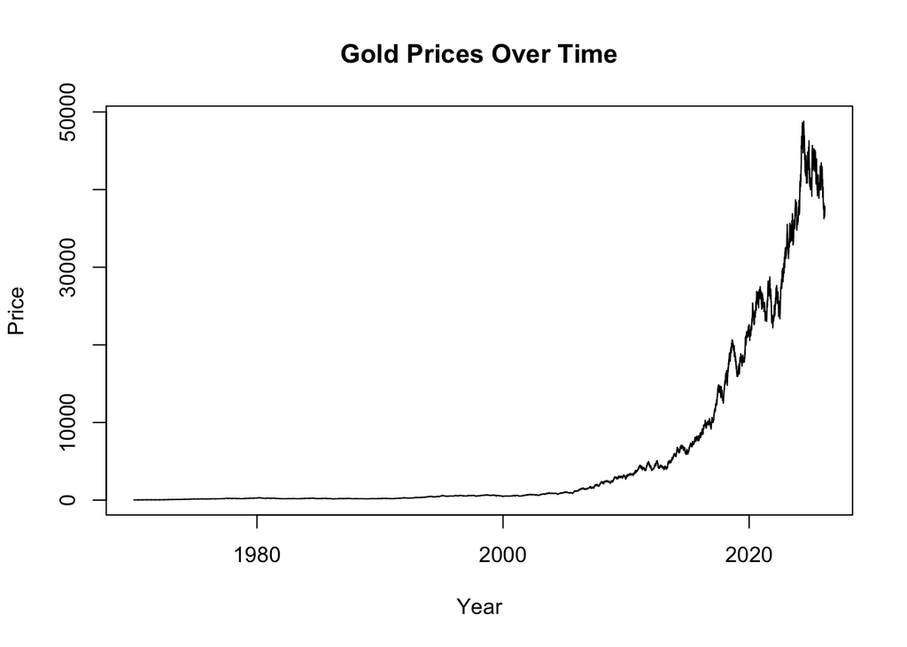

```r
plot(prophet_data$ds, prophet_data$y, type = "l",
     main = "Gold Prices Over Time",
     xlab = "Year", ylab = "Price")
```

The plot shows a clear long term upward trend in gold prices. There are periods of volatility and sharper increases, particularly after the early 2000s, which indicates changing market conditions.

# 4. Model Building

## 4.1 Log transformation

```r
prophet_data$y <- log(prophet_data$y)
```

A logarithmic transformation is applied here to stabilise variance and capture growth patterns better.

## 4.2 Fitting the model

```r
library(prophet)
gold_model <- prophet(prophet_data)
```

```
## Disabling daily seasonality. Run prophet with daily.seasonality=TRUE to override this.
```

The Prophet model is fitted using the log transformed data. Important to note it shows log transformed gold prices and not actual prices.

## 4.3 Forecasting

```r
future_dates <- make_future_dataframe(gold_model, periods = 365)
gold_forecast <- predict(gold_model, future_dates)
```

The model forecasts gold prices one year into the future(1 year is 365 days)

# 5. Results

## 5.1 Forecast plot

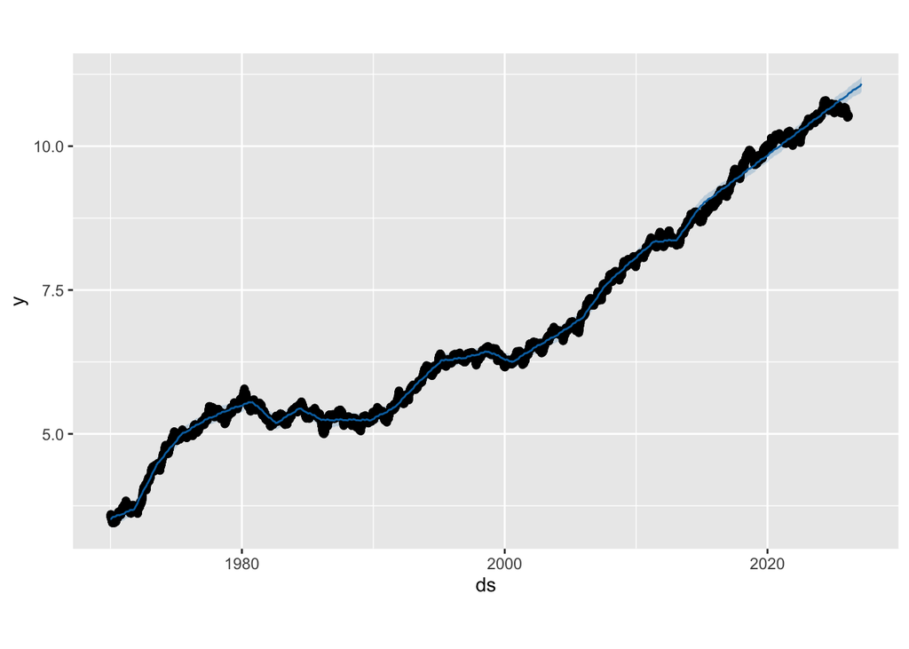

```r
plot(gold_model, gold_forecast)
```

This plot shows historical log-transformed prices along with the forecast. The blue line represents predicted values, while the shaded region represents uncertainty intervals. The forecast indicates continued upward growth with increasing uncertainty over time.

## 5.2 Model components

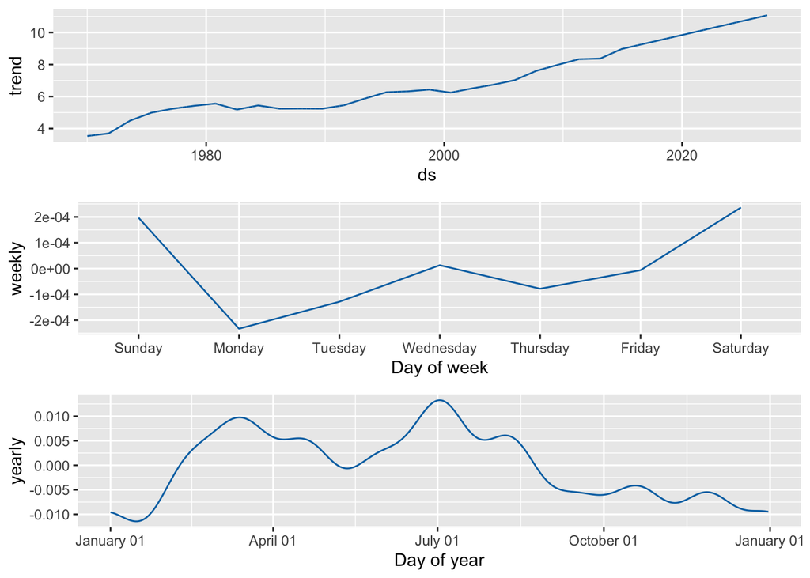

```r
prophet_plot_components(gold_model, gold_forecast)
```

The components plot breaks the forecast into trend and seasonal effects:

- The **Trend (Top) component** shows long-term movement of gold prices (log scale): *X-axis shows the time* Y-axis shows the trend value *Observed:* Strong upward trend from 1970 to 2025 *Slight flattening around 1980 to 2000* Faster growth after 2000
- The **Weekly (Middle) component** shows the effect of day of the week on prices *X-axis shows the days* Y-axis shows the small effect on price *Observed:* Slight dip on Monday *Increase towards weekend (Saturday highest)* Day of week has little impact on gold prices
- The **Yearly (Bottom) component** shows the effect of time of year *X-axis shows the day of year (can look at the year in quarters for better understanding)* Y-axis shows the seasonal effect *Observed:* Peaks around the middle of the year *Dips towards the end and start of the year* Some seasonal pattern but relatively small compared to the the trend.

All components are in log scale, so seasonal effects represent proportional changes rather than absolute price differences Overall, the trend is the dominant factor driving gold prices.

## 5.3 Converting back to original scale

```r
tail(gold_forecast[, c("ds", "yhat", "yhat_lower", "yhat_upper")])
```

```
##               ds     yhat yhat_lower yhat_upper
## 20872 2027-02-22 11.07818   10.93325   11.20737
## 20873 2027-02-23 11.07905   10.95442   11.20406
## 20874 2027-02-24 11.07995   10.95123   11.21959
## 20875 2027-02-25 11.08063   10.93989   11.20961
## 20876 2027-02-26 11.08147   10.95518   11.21386
## 20877 2027-02-27 11.08248   10.94237   11.22200
```

```r
gold_forecast$price <- exp(gold_forecast$yhat)
gold_forecast$price_lower <- exp(gold_forecast$yhat_lower)
gold_forecast$price_upper <- exp(gold_forecast$yhat_upper)

tail(gold_forecast[, c("ds", "price", "price_lower", "price_upper")])
```

```
##               ds    price price_lower price_upper
## 20872 2027-02-22 64742.74    56008.04    73671.19
## 20873 2027-02-23 64799.10    57206.51    73428.04
## 20874 2027-02-24 64857.86    57024.01    74577.48
## 20875 2027-02-25 64901.64    56381.41    73836.88
## 20876 2027-02-26 64956.12    57249.77    74150.87
## 20877 2027-02-27 65021.88    56521.11    74757.39
```

Since the model was fitted on log transformed data, predictions are converted back to actual prices using the exponential function. This provides interpretable forecasts along with uncertainty ranges.

# 6. Model Comparisons

```r
model_no_season <- prophet(prophet_data, yearly.seasonality = FALSE)
```

```
## Disabling daily seasonality. Run prophet with daily.seasonality=TRUE to override this.
```

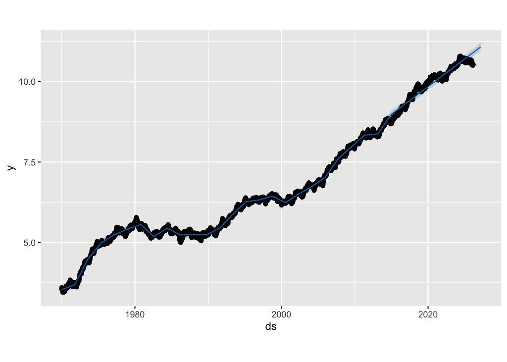

```r
future2 <- make_future_dataframe(model_no_season, periods = 365)
forecast2 <- predict(model_no_season, future2)

plot(model_no_season, forecast2)
```